# 2.6. Data Import

Suppose we have a file of pure numbers (univariate data) that we want to read into R. For example, assume that the `mpg` data is stored in file called mpg.txt literally as shown.

```
21.0 21.0 22.8 21.4 18.7
18.1 14.3 24.4 22.8 19.2
17.8 16.4 17.3 15.2 10.4
10.4 14.7 32.4 30.4 33.9
21.5 15.5 15.2 13.3 19.2
27.3 26.0 30.4 15.8 19.7
15.0 21.4
```

Such data can be read into R thus:

```r
mpg <- base::scan(file = "./mpg.txt")
str(mpg)
```

```
##  num [1:32] 21 21 22.8 21.4 18.7 18.1 14.3 24.4 22.8 19.2 ...
```

# 2.6.1. Coding Style Note

When R functions take arguments, it is always a good idea to use *named* arguments where possible as shown above in the `scan` invocation. This is something to be aware of for your project.

# 2.6.2. Delimited Files

Things get more interesting if data is multivariate or delimited.

- Delimited files (comma / tab) are commonly used to store multivariate data.
- To read such data correctly into a data frame, the data has to be properly structured. For example, each row must have the same number of items or some hints have to be provided to handle unusual situations.

It helps to be defensive!

In what follows, we will prefer the package `readr` to handle external data rather than what base R provides.

### 2.6.3. Mt. Umunhum Rainfall data

The Santa Clara Valley Water District has a number of sensors that record rainfall and water levels at reservoirs. The data can be downloaded using [their website](http://alert.valleywater.org/). (The site can be down at times!).

### 2.6.3.1. Closer inspection

We will use `readr::read_csv` instead of base R’s `utils::read.csv`.

```r
library(readr)
```

The R function `read_csv` in the package `readr` will read a comma separated (and other delimited) file and create a `tibble` out of it.

*What is a tibble?* A modern take on data frames. They behave like data frames *mostly*, but are also faster; see this [vignette](https://cloud.r-project.org/web/packages/tibble/vignettes/tibble.html) and also [Chapter 10. Tibbles](https://r4ds.had.co.nz/tibbles.html) of *R for Data Science.*

Let’s try directly.

```r
mtu <- readr::read_csv(file = "./mtumunhum.csv")
```

```
## Warning: 343 parsing failures.
## row col  expected    actual              file
##  20  -- 1 columns 3 columns './mtumunhum.csv'
##  21  -- 1 columns 3 columns './mtumunhum.csv'
##  22  -- 1 columns 3 columns './mtumunhum.csv'
##  23  -- 1 columns 3 columns './mtumunhum.csv'
##  24  -- 1 columns 3 columns './mtumunhum.csv'
## ... ... ......... ......... .................
## See problems(...) for more details.
```

```r
str(mtu)
```

```
## Classes 'spec_tbl_df', 'tbl_df', 'tbl' and 'data.frame': 362 obs. of  1 variable:
##  $ # -------------------------------------NOTICE------------------------------------------: chr  "# These data readings are Preliminary." "#" "# Most data relayed by telemetry have received little or no review." "# Inaccuracies in the data may be present because of instrument" ...
##  - attr(*, "problems")=Classes 'tbl_df', 'tbl' and 'data.frame': 343 obs. of  5 variables:
##   ..$ row     : int  20 21 22 23 24 25 26 27 28 29 ...
##   ..$ col     : chr  NA NA NA NA ...
##   ..$ expected: chr  "1 columns" "1 columns" "1 columns" "1 columns" ...
##   ..$ actual  : chr  "3 columns" "3 columns" "3 columns" "3 columns" ...
##   ..$ file    : chr  "'./mtumunhum.csv'" "'./mtumunhum.csv'" "'./mtumunhum.csv'" "'./mtumunhum.csv'" ...
##  - attr(*, "spec")=
##   .. cols(
##   ..   `# -------------------------------------NOTICE------------------------------------------` = col_character()
##   .. )
```

Although `mtu` is a `tibble`, it is not at all what we expected, although we got a hint of some problems from the warnings spewed out by the `read_csv` invocation. So this calls for some examination of the actual data by reading say the first 25 lines of the file.

```r
readr::read_lines(file = "./mtumunhum.csv", n_max = 25)
```

```
##  [1] "# -------------------------------------NOTICE------------------------------------------"
##  [2] "# These data readings are Preliminary."
##  [3] "#"
##  [4] "# Most data relayed by telemetry have received little or no review."
##  [5] "# Inaccuracies in the data may be present because of instrument"
##  [6] "# malfunctions and/or physical changes at the measurement site."
##  [7] "#"
##  [8] "# Subsequent review may result in significant revisions to the data."
##  [9] "#"
## [10] "# Retrieved: 2020-01-08 08:55:38 (PST)"
## [11] "# (Note: Gage clock may be different from current time)"
## [12] "#"
## [13] "# This file contains data for 1 Mount Umunhum (6069) sensor(s):"
## [14] "#   2081"
## [15] "#"
## [16] "# -------------------------------------------------------------------------------------"
## [17] "#"
## [18] "# Data provided for Mount Umunhum (6069) sensors"
## [19] "#   over the period of '2019/12/01' to '2020/01/07'"
## [20] "#"
## [21] ""
## [22] "Sensor ID,Date and Time (PST),Value (in)"
## [23] "2081,2020-01-07 07:54:20,15.87"
## [24] "2081,2020-01-06 19:54:20,15.87"
## [25] "2081,2020-01-06 07:54:20,15.87"
```

Line 22 describes what is being measured. The actual data starts in line 23. Therefore, we need to skip the first 21 lines to get at the data. This is all too common a phenomenon, where a file is expected to be a comma separated file (because it has a file extension `.csv`) but the reality is ruder.

### 2.6.3.2. Second Try

Our second try where we ask `read_csv` to skip the first 21 lines.

```r
mtu <- read_csv(file = "./mtumunhum.csv", skip = 21)
```

Now things seem much better, so let us see.

```r
str(mtu)
```

```
## Classes 'spec_tbl_df', 'tbl_df', 'tbl' and 'data.frame': 342 obs. of  3 variables:
##  $ Sensor ID          : num  2081 2081 2081 2081 2081 ...
##  $ Date and Time (PST): POSIXct, format: "2020-01-07 07:54:20" "2020-01-06 19:54:20" ...
##  $ Value (in)         : num  15.9 15.9 15.9 15.9 15.9 ...
##  - attr(*, "spec")=
##   .. cols(
##   ..   `Sensor ID` = col_double(),
##   ..   `Date and Time (PST)` = col_datetime(format = ""),
##   ..   `Value (in)` = col_double()
##   .. )
```

The first few lines.

```r
head(mtu)
```

```
## # A tibble: 6 x 3
##   `Sensor ID` `Date and Time (PST)` `Value (in)`
##         <dbl> <dttm>                       <dbl>
## 1        2081 2020-01-07 07:54:20           15.9
## 2        2081 2020-01-06 19:54:20           15.9
## 3        2081 2020-01-06 07:54:20           15.9
## 4        2081 2020-01-05 07:54:16           15.9
## 5        2081 2020-01-04 19:54:21           15.9
## 6        2081 2020-01-04 07:54:21           15.9
```

**ASIDE** What one should never do is to edit the file to remove problematic lines. Instead handle things in code, so that your solution can be employed in a pipeline.

### 2.6.3.4. Difference between `utils::read.csv` and `readr::read_csv`

This is a good point in the discussion to once again reiterate some differences between `readr::read_csv` and `utils::read.csv`.

```r
mtu2 <- read.csv(file = "./mtumunhum.csv", skip = 21)
str(mtu2)
```

```
## 'data.frame':    342 obs. of  3 variables:
##  $ Sensor.ID          : int  2081 2081 2081 2081 2081 2081 2081 2081 2081 2081 ...
##  $ Date.and.Time..PST.: Factor w/ 342 levels "2019-12-01 00:25:57",..: 342 341 340 339 338 337 336 335 334 333 ...
##  $ Value..in.         : num  15.9 15.9 15.9 15.9 15.9 ...
```

Notice several things.

- `utils::read.csv` converted the dates to factors, which is, of course, problematic
- The variable `Date and Time` was automatically renamed! Can you suggest why?

Assuming that these kinds of transformations should be performed by default can be troublesome for several reasons.

- They can be expensive when the data is large
- They may be unnecessary because you may want to do something else with the data
- They can lead to troublesome code; for example, you may glibly assume that the column names like `Date and Time` will not have spaces when they actually do.
- You also have limited parsing options for other types of data such as dates and times

*Therefore I recommend using `readr` wherever possible as it is far more flexible.*

# 2.6.4. Plotting rainfall

Once we have the data, of course, we can do many useful things with it. That will be the topic of material to follow, but here is a simple plot of the cumulative level against date and time.

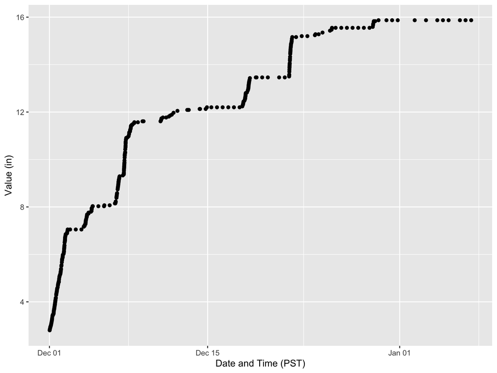

```r
library(ggplot2)
ggplot2::qplot(x = `Date and Time (PST)`, y = `Value (in)`, data = mtu)
```

# 2.6.5. Save The Data

We might use this data later so we save this version of the data (to avoid going through the steps again) for future use in a file `mtu.RDS`.

```r
saveRDS(mtu, "./mtu.RDS")
```